# i promise this is the last one for a while: audio generation with elevenlabs

tutorial

ai

experiments

audio

elevenlabs

you do not have to hear yourself in experiments, and you can generate experiment instructions with ai. here is how.

Author

Utku Turk

Published

February 24, 2026

Hi. Unfortunately, this blog turned into a mini series about AI stuff, and I promise this is the last one for a while. In this post, I share a quick way to generate sentence audio with AI. It still sounds synthetic sometimes, even if it no longer sounds robotic, so randomizing a few parameters helps. It is free online without coding. If you want to do it in bulk with more control, you can use the ElevenLabs API. It is 5 dollars a month, and you can cancel it anytime.

A bit of backstory first. In my first production experiment, we did a lot of handholding because it was online and we assumed people would struggle with the task. And yes, people **do** struggle in these kinds of experiments. Still, the extra handholding did not change much. One part of that handholding was audio instructions. Everyone who knows me knows I am very skeptical about how much attention participants pay in online experiments. Most of the time, people just do the easiest thing that still gets them through, so I did not fully trust that participants would read the instructions carefully. That is why I wanted audio instructions too.

Since I am around many native English speakers, getting recordings was easy at first. Andrea Zukowski, with her insanely soothing voice, was one of the best people to ask, and she recorded several sentences for my first experiment. But this was not scalable. I could not keep asking her for every new experiment. At the same time, I was already knee-deep in AI voice-transcription tools for other parts of the project, like automatic transcription and forced alignment, so I thought: why not use AI here too?

If you are reading this and thinking, “Is Utku’s experiment just Utku prompting AI stuff?”, the answer is no. The tools are useful, but there is still a lot of manual work. After generating pictures, I still had to sift through many options and verbs to find usable ones. The same goes for audio generation and transcription: you still need to review outputs and catch mistakes one by one.

In the end, I did not use AI-generated audio in my English production experiments, but the code was ready. Later, Yagmur and I ran experiments in Turkish as part of a multilingual project initiated by Florian Schwarz. They were looking at strong vs. weak determiners across languages, related to his dissertation: https://florianschwarz.net/FSDiss/FS-Diss_singlespace.pdf. The title of the talk was *Exploring the contrast between weak and strong definite articles experimentally*. The experiment itself was designed as a game: participants heard sentences with either strong or weak determiners modifying nouns, then chose an item based on what they heard.

The ElevenLabs API is straightforward to use: https://elevenlabs.io/docs/developers/quickstart. It also gives you 10,000 free credits per month (about 10 minutes of recordings), which is generous and enough for many experiments. I am paying 5 dollars a month for the API when I need it and cancel it later, which gives you ~40 minutes of recording. If needed, you can pay 22 USD for one month and use their Professional Voice Cloning feature. That plan gives you 100k credits (about 100 minutes). Before running the code, get your API key from ElevenLabs: https://elevenlabs.io/app/developers/api-keys. After that, either set it as an environment variable or load it from a `.env` file with `dotenv`.

```python
import os
from pathlib import Path
from dotenv import load_dotenv
from elevenlabs import VoiceSettings
from elevenlabs.client import ElevenLabs
import pandas as pd


load_dotenv(dotenv_path=Path.home() / '.env.global')

api_key = os.getenv("ELEVENLABS_API_KEY")

client = ElevenLabs(
    api_key=api_key,
)
```

Now, we mainly need three things from the SDK:

- `ElevenLabs()`: to initialize the client with your API key. Creates the connection to ElevenLabs’ API.
- `elevenlabs.text_to_speech.convert()`: The core function that converts your text into speech audio. Takes text input, voice ID, and settings, returns audio data.
- `VoiceSettings()`: Configures voice parameters like:
  - `stability`: Controls how much the voice varies. Higher values make it more consistent, lower values make it more dynamic.
  - `similarity_boost`: Adjusts how closely the generated voice matches the original voice. Higher values make it sound more like the original, while lower values allow for more variation.
  - `style`: Changes the speaking style of the voice (e.g., “default”, “newscaster”, “narration”, etc.).
  - `speed`: Modifies the speaking speed. Values greater than 1.0 make it faster, while values less than 1.0 make it slower.
  - `pitch`: Alters the pitch of the voice. Values greater than 1.0 make it higher, while values less than 1.0 make it lower.
  - `use_speaker_boost`: Enhances the distinctiveness of the speaker’s voice.

Before all of this, we need to pick a voice. This is where I spend most of the time. ElevenLabs has many built-in voices, and you can also create your own: https://elevenlabs.io/voices. You can filter by language, style, and more.

After selecting a voice, you can get the voice ID from the URL. For example, if you choose “Ece” (a Turkish voice), the URL will look like `https://elevenlabs.io/voices/voice_id=gyxPK6bLXQAkBSCeAKvk`, and the voice ID is `gyxPK6bLXQAkBSCeAKvk`.

A simple convert example. This is the main workhorse call that turns text into speech.

```python
sample_file = "simple_example.mp3"

response = client.text_to_speech.convert(
    voice_id="gyxPK6bLXQAkBSCeAKvk",
    output_format="mp3_22050_32",
    text="Diğer blog postlarını okumayı unutmayın!",
    model_id="eleven_turbo_v2_5",
    voice_settings=VoiceSettings(
        stability=0.71,
        similarity_boost=0.42,
        style=0.36,
        use_speaker_boost=True,
        speed=0.9,
    ),
)

with open(sample_file, "wb") as f:
    for chunk in response:
        if chunk:
            f.write(chunk)

print(f"Saved: {sample_file}")
```

```
Saved: simple_example.mp3
```

**Show audio preview code**

```python
from IPython.display import Audio, display

display(Audio(filename=sample_file))
```

[interactive chart not shown]

**Show praat plot generation code**

```
Saved Praat plot: simple_example_praat.png
```

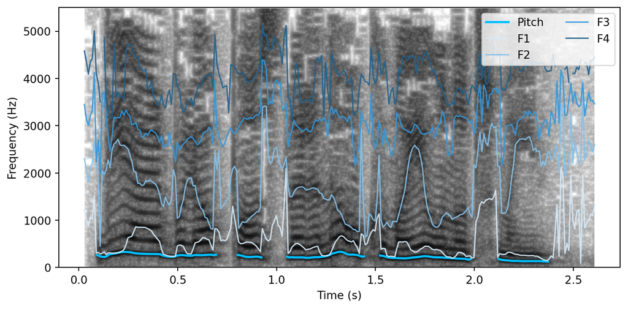

```python
import numpy as np
import matplotlib.pyplot as plt
import parselmouth

sound = parselmouth.Sound(sample_file)
spectrogram = sound.to_spectrogram(window_length=0.03, maximum_frequency=5500)
pitch = sound.to_pitch(time_step=0.01, pitch_floor=75, pitch_ceiling=500)
formants = sound.to_formant_burg(
    time_step=0.01,
    max_number_of_formants=5,
    maximum_formant=5500,
    window_length=0.025,
    pre_emphasis_from=50,
)

x = spectrogram.x_grid()
y = spectrogram.y_grid()
sg_db = 10 * np.log10(spectrogram.values + 1e-12)

plt.figure(figsize=(8, 4))
plt.pcolormesh(x, y, sg_db, shading="auto", cmap="gray_r")
plt.ylim(0, 5500)
plt.xlabel("Time (s)")
plt.ylabel("Frequency (Hz)")
# plt.title(f"Praat-style view: {sample_file}")

pitch_values = pitch.selected_array["frequency"]
pitch_values[pitch_values == 0] = np.nan
plt.plot(pitch.xs(), pitch_values, color="deepskyblue", linewidth=2, label="Pitch")

times = np.array(formants.ts())
for idx, color in zip([1, 2, 3, 4], ["#d6eaf8", "#85c1e9", "#3498db", "#21618c"]):
    vals = np.array([formants.get_value_at_time(idx, t) for t in times], dtype=float)
    vals[(vals <= 0) | (vals > 5500)] = np.nan
    plt.plot(times, vals, color=color, linewidth=1.2, alpha=0.9, label=f"F{idx}")

plt.legend(loc="upper right", ncol=2)
plt.tight_layout()
praat_plot_file = "simple_example_praat.png"
plt.savefig(praat_plot_file, dpi=300, bbox_inches="tight")
print(f"Saved Praat plot: {praat_plot_file}")
plt.show()
```

However, we should not use the exact same settings for every sentence. That would sound too monotone, and participants may lose interest, so we vary a few parameters to introduce controlled variation. For example, we can randomize speed, but we still do not want extreme variation. Good simple options are truncated exponential, log-normal, and normal distributions; the choice mostly depends on what you like. Let us plot them first. (You can also use uniform, but I do not like it much here.)

Since we truncate each distribution, their final shapes differ slightly:

- Exponential: Right skewed, more slow speech
- Reverse Exponential: Left skewed, more fast speech
- Log-normal: almost beta-like; the mean is around 1.0, but both tails are more likely.
- Normal: symmetric; the mean is around 1.0, with less mass in the tails.

**Show distribution sampling code**

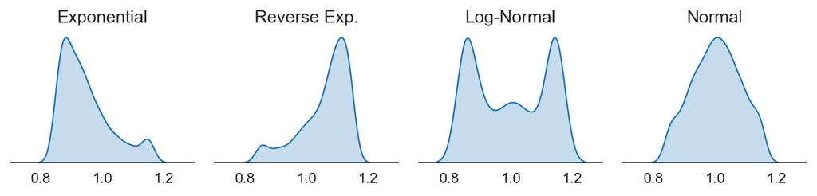

```python
import numpy as np
import matplotlib.pyplot as plt
import seaborn as sns

clip_low, clip_high = 0.85, 1.15
n = 1000

# Exponential: shifted to center around 1.0 (right-skewed)
exp_samples = np.clip(0.85 + np.random.exponential(0.1, n), clip_low, clip_high)

# Reverse Exponential: left-skewed (more fast speech)
rev_exp_samples = np.clip(1.15 - np.random.exponential(0.1, n), clip_low, clip_high)

# Log-normal: median at 1.0 (beta-like)
lognorm_samples = np.clip(np.random.lognormal(0, 0.20, n), clip_low, clip_high)

# Normal: centered at 1.0 (symmetric)
norm_samples = np.clip(np.random.normal(1.0, 0.08, n), clip_low, clip_high)

sns.set_style('white')
fig, axes = plt.subplots(1, 4, figsize=(8, 2))

distributions = [
    (exp_samples, 'Exponential'),
    (rev_exp_samples, 'Reverse Exp.'),
    (lognorm_samples, 'Log-Normal'),
    (norm_samples, 'Normal')
]

for ax, (samples, title) in zip(axes, distributions):
    sns.kdeplot(samples, fill=True, ax=ax)
    ax.set_xlim(0.7, 1.3)
    ax.set_title(title)
    ax.set_xlabel('')
    ax.set_ylabel('')
    ax.set_yticks([])
    ax.spines['left'].set_visible(False)
    ax.spines['top'].set_visible(False)
    ax.spines['right'].set_visible(False)

plt.tight_layout()
plt.show()
```

For my own experiments, I use a clipped log-normal. In real life, speech is often a bit slower or faster than expected. I do not want too many sentences exactly at 1.0, but I also do not want many extremely slow or fast ones.

For stability, similarity boost, and style, I keep variation small. I sample each around a preferred value with a low standard deviation, because I mainly want variation in speed.

- stability: normal distribution around 0.71
- similarity boost: normal distribution around 0.42
- style: normal distribution around 0.36

The function below, `text_to_speech_file`, takes text and a file name, generates audio, randomizes speed with a log-normal distribution, and randomizes stability/similarity/style with normal distributions. It then saves the result as an mp3 file.

```python
def text_to_speech_file(text: str, fname, clip_low = 0.85, clip_high = 1.15) -> str:

    speed = float(np.clip(np.random.lognormal(0, 0.20), clip_low, clip_high))
    stability = float(np.clip(np.random.normal(0.71, 0.05), 0, 1))
    similarity_boost = float(np.clip(np.random.normal(0.42, 0.05), 0, 1))
    style = float(np.clip(np.random.normal(0.36, 0.05), 0, 1))

    response = client.text_to_speech.convert(
        voice_id="gyxPK6bLXQAkBSCeAKvk",
        output_format="mp3_22050_32",
        text=text,
        model_id="eleven_turbo_v2_5",

        voice_settings=VoiceSettings(
            stability=stability,
            similarity_boost=similarity_boost,
            style=style,
            use_speaker_boost=True,
            speed=speed,
        ),
    )

    save_file_path = f"{fname}"

    with open(save_file_path, "wb") as f:
        for chunk in response:
            if chunk:
                f.write(chunk)

    print(f"{save_file_path}: A new audio file was saved successfully!")

    return save_file_path
```

Assuming you have a CSV file with `text` and `target_file` columns, the following code generates audio files row by row and saves each one with its target name.

```python
df = pd.read_csv('./data.csv')

df = df[['item', 'condition', 'text', 'target_file']]

df = df.drop_duplicates(subset=['target_file'])

for index, row in df.iterrows():
    text_to_speech_file(row['text'], row['target_file'])
```

```
item01_weak.mp3: A new audio file was saved successfully!
item01_strong.mp3: A new audio file was saved successfully!
item02_weak.mp3: A new audio file was saved successfully!
item02_strong.mp3: A new audio file was saved successfully!
item03_weak.mp3: A new audio file was saved successfully!
item03_strong.mp3: A new audio file was saved successfully!
item04_weak.mp3: A new audio file was saved successfully!
item04_strong.mp3: A new audio file was saved successfully!
item05_weak.mp3: A new audio file was saved successfully!
item05_strong.mp3: A new audio file was saved successfully!
item06_weak.mp3: A new audio file was saved successfully!
item06_strong.mp3: A new audio file was saved successfully!
```

And to quickly sanity-check what was generated, here’s a small code for previewing the first few files in a Jupyter notebook. It checks if the generated files exist, and if they do, it creates an audio player for each one. If no files are found, it prompts you to run the generation cell first.

**Show df-audio preview code**

```python
from IPython.display import HTML, display

preview_df = df.copy()
preview_df["file_exists"] = preview_df["target_file"].apply(lambda f: Path(f).exists())
preview_df = preview_df[preview_df["file_exists"]].head(6)

def audio_player(path):
    return (
        f'<audio controls preload="none" style="width:220px;">'
        f'<source src="{path}" type="audio/mpeg">'
        f"Your browser does not support the audio element."
        f"</audio>"
    )

if preview_df.empty:
    print("No generated audio files found yet. Run the generation cell first.")
else:
    preview_df["preview"] = preview_df["target_file"].apply(audio_player)
    display(
        HTML(
            preview_df[["item", "condition", "text", "target_file", "preview"]]
            .to_html(index=False, escape=False)
        )
    )
```

| item | condition | text | target_file | preview |
| --- | --- | --- | --- | --- |
| 1 | weak | Bana pastayı verebilir misin rica etsem? | item01_weak.mp3 |  |
| 1 | strong | Bana o pastayı verebilir misin rica etsem? | item01_strong.mp3 |  |
| 2 | weak | Bana kurabiyeyi verebilir misin rica etsem? | item02_weak.mp3 |  |
| 2 | strong | Bana o kurabiyeyi verebilir misin rica etsem? | item02_strong.mp3 |  |
| 3 | weak | Bana ekmeği verebilir misin rica etsem? | item03_weak.mp3 |  |
| 3 | strong | Bana o ekmeği verebilir misin rica etsem? | item03_strong.mp3 |  |

```python
import os
from mutagen.mp3 import MP3

def list_long_mp3_files(file_paths, max_duration=4):
    long_files = []
    for file_path in file_paths:
        audio = MP3(file_path)
        duration = audio.info.length
        if duration > max_duration:
            long_files.append(os.path.basename(file_path))
    return long_files

folder_path = '.'
all_files = [os.path.join(folder_path, f"{fname}") for fname in df['target_file']]
long_files = list_long_mp3_files(all_files, max_duration=4)
long_files_set = set(long_files)

for index, row in df.iterrows():
    if f"{row['target_file']}" in long_files_set:
        text_to_speech_file(row['text'], row['target_file'])
```

A few extra notes.

- In addition to normal text, you can give some special code in the text. For example, you can use `<break time="500ms"/>` to add a pause of 500 milliseconds.
- You can also utilize IPA phonetic transcription for better pronunciation. Interestingly, you can even put breaks between IPA symbols to manipulate data more. For example, instead of “cat”, you can use `"k<break time='100ms'/>æ<break time='100ms'/>t"` to add slight pauses between the phonetic components. This is extremely useful if you want to align some recordings specifically.
- You can also add narrative cues. For example, instead of just “The cat is on the table”, you can use “‘The cat is on the table,’ she said in a surprised tone”.
- You can also add tags like `[whispers]`, `[sighs]`, `[excited]`, or sound effects like `[swallows]`.